# (Airline Delay Exploration)

## by (Hany Abdol-Aleem Ghazal)

## Investigation Overview

> Visualizing relationships between airline delay and contributing factors.

## Dataset Overview

> The dataset represents various factors affecting airline delay such as carrier, weather and other factors.

## (Visualization 1)

### 1- Number of flights having >= 15 minutes delay

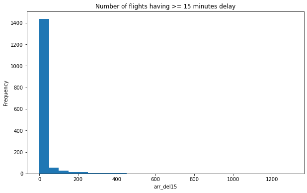

```python
bins = np.arange(0, df.arr_del15.max()+50, 50)
plt.figure(figsize=[10, 6])
plt.hist(data=df, x='arr_del15', bins=bins)
plt.title('Number of flights having >= 15 minutes delay')
plt.xlabel('arr_del15')
plt.ylabel('Frequency')
```

> *As we see below the plots are difficult to interpret and shows the presence of outliers.*

> *There is a long tail that tell us about the presence of outliers => So I will do scale transformation changing from linear to log scale to better depict tha data.*

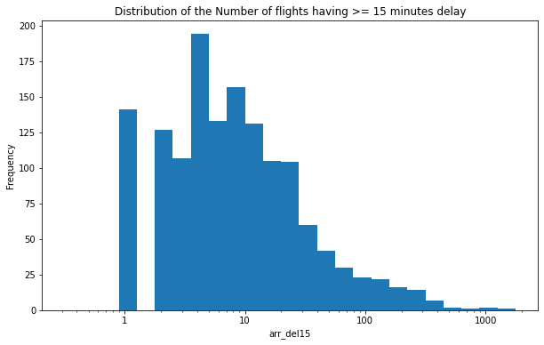

```python
max = np.log10(df.arr_del15.describe())['max']
bins = 10 ** np.arange(-0.5, max+0.15, 0.15)
plt.figure(figsize=[10, 6])
plt.hist(data=df, x='arr_del15', bins=bins);
plt.xscale('log')
plt.xticks([1, 10, 100, 1000], [1, 10, 100, 1000])
plt.title('Distribution of the Number of flights having >= 15 minutes delay')
plt.xlabel('arr_del15')
plt.ylabel('Frequency')
```

> *This is a right-skewed distribution of the feature arr_del15*

### 2- Distribution of Total Number of Delay Minutes

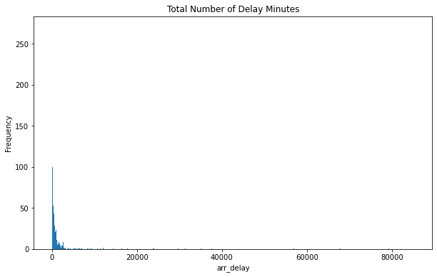

```python
bins = np.arange(0, df.arr_delay.max()+50, 50)
plt.figure(figsize=[10, 6])
plt.hist(data=df, x='arr_delay', bins=bins)
plt.title('Total Number of Delay Minutes')
plt.xlabel('arr_delay')
plt.ylabel('Frequency')
```

> *The linear scale here makes the plot difficult to interpret.*

> *Also there are outliers*

> *Scale transformation using log scale is the solution.*

[figure not shown]

```python
max = np.log10(df.arr_delay.describe())['max']
bins = 10 ** np.arange(1, max+0.15, 0.15)
plt.figure(figsize=[10, 6])
plt.hist(data=df, x='arr_delay', bins=bins);
plt.xscale('log')
plt.xticks([1e1, 1e2, 1e3, 1e4, 1e5], [10, 100, '1K', '10K', '500K'])
plt.title('Distribution of Total Number of Delay Minutes')
plt.xlabel('arr_delay')
plt.ylabel('Frequency')
```

> *The distribution of arr_delay is normal distribution that is shown via a better scale.*

## Summary 1

> *The distributions of arr_del15 is right skewed.*

> *The distributions of arr_delay is normal.*

> *There are outliers and the plots are difficult to interpret => So we needed scale transformation changing to the log scale for better depiction of data.*

## (Visualization 2)

### 1- arr_del15 and arr_delay relationship

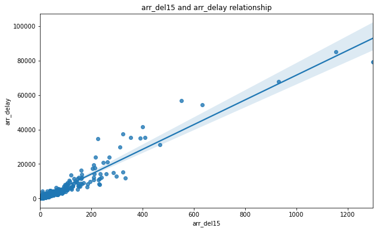

```python
plt.figure(figsize=[10, 6])
sb.regplot(data=df, x='arr_del15', y='arr_delay');
# plt.xscale('log')
plt.xlabel('arr_del15')
plt.ylabel('arr_delay')
plt.title('{} and {} relationship'.format('arr_del15', 'arr_delay'))
```

> *There is a collapse in data points that necessitates scale transformation.*

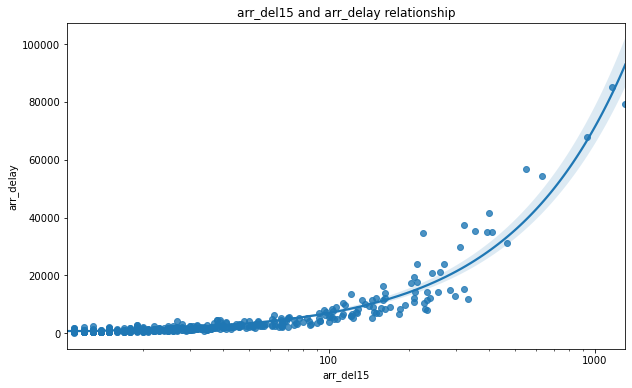

```python
plt.figure(figsize=[10, 6])
sb.regplot(data=df, x='arr_del15', y='arr_delay');
plt.xscale('log')
plt.xticks([1e2, 1e3], [100, 1000])
plt.xlabel('arr_del15')
plt.ylabel('arr_delay')
plt.title('{} and {} relationship'.format('arr_del15', 'arr_delay'))
```

> *Changing to log scale give better representation of data points.*

### 2- Relationship between arr_del15 and others contributers.

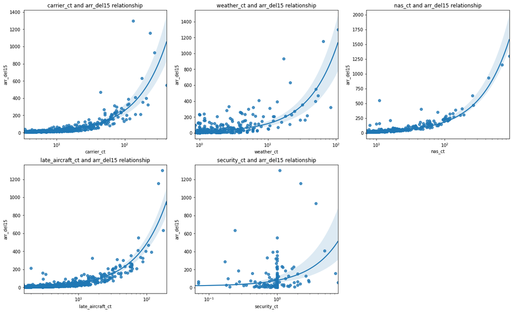

```python
def plot_pairs(dict):
    x_vars = list(dict.values())[0]
    y_var = list(dict.keys())[0]
    length = len(x_vars)
    plt.figure(figsize=[20, 12])
    for i in range(length):
        plt.subplot(math.ceil(length/3), 3, i+1)
#         plt.scatter(data=df, x=x_vars[i], y=y_var)
        sb.regplot(data=df, x=x_vars[i], y=y_var)
        plt.xscale('log')
        plt.xlabel(x_vars[i])
        plt.ylabel(y_var)
        plt.title('{} and {} relationship'.format(x_vars[i], y_var))
dict1 = {'arr_del15':['carrier_ct', 'weather_ct', 'nas_ct', 'late_aircraft_ct', 'security_ct']}
plot_pairs(dict1)
```

> *I noticed that arr_del15 feature varies with variations in carrier_ct, weather_ct, nas_ct and late_aircraft_ct more than with security_ct with a higher slope indicating a more strong positive correlation.*

### 3- Relation between arr_delay and other contributers.

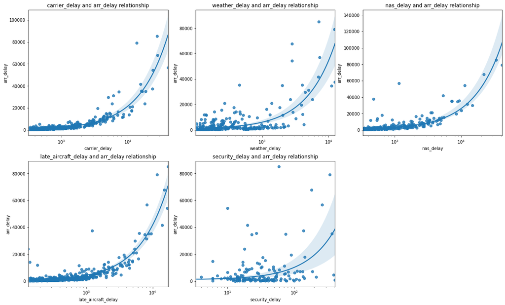

```python
dict2 = {'arr_delay':['carrier_delay', 'weather_delay', 'nas_delay', 'late_aircraft_delay', 'security_delay']}
plot_pairs(dict2)
```

> *I noticed that arr_delay feature varies with variations in carrier_delay, weather_delay, nas_delay and late_aircraft_delay more than with security_delay with a higher slope indicating a more strong positive correlation.*

## (Visualization 3)

### Relationship between ( arr_del15 and arr_delay ) and carrier_ct, nas_ct and nas_delay.

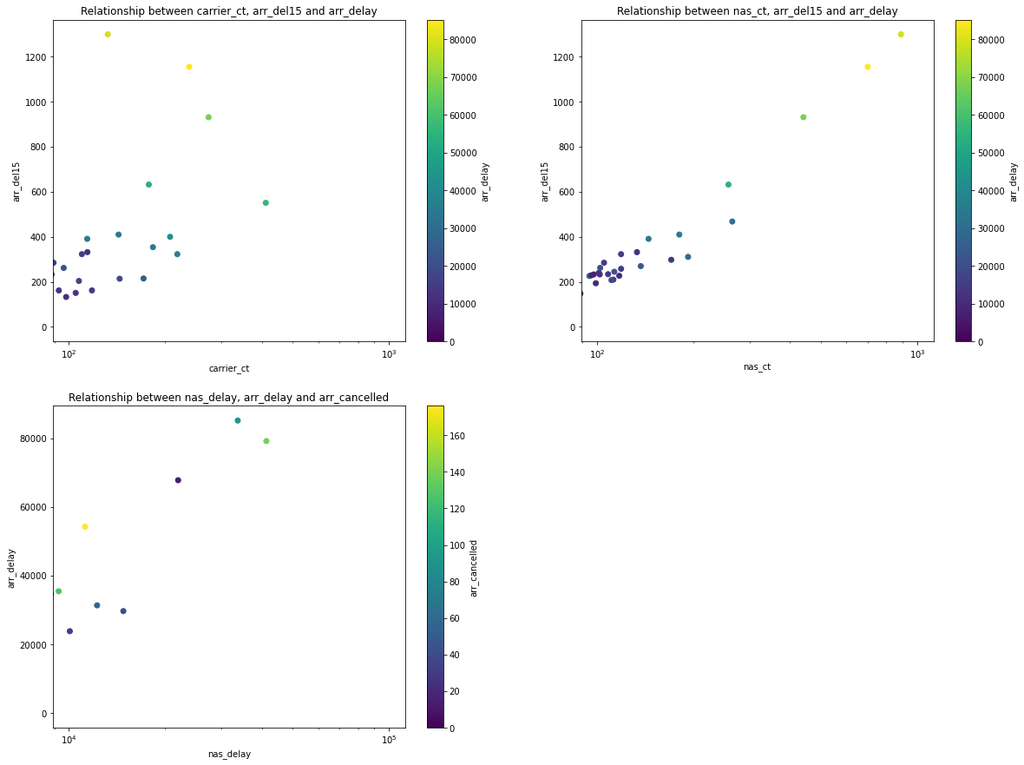

```python
def plot_multiple(dict_list):
    plt.figure(figsize=[20, 15])
    length = len(dict_list)
    for i in range(len(dict_list)):
        plt.subplot(math.ceil(length/2), 2, i+1)
        plt.scatter(data=df, x=dict_list[i]['x'], y=dict_list[i]['y'], c=dict_list[i]['c']);
        plt.colorbar(label=dict_list[i]['c'])
        plt.xscale('log')
        plt.xlabel(dict_list[i]['x'])
        plt.ylabel(dict_list[i]['y'])
        plt.title('Relationship between {}, {} and {}'.format(dict_list[i]['x'], dict_list[i]['y'], dict_list[i]['c']))

dict_list = [
    {'x':'carrier_ct', 'y':'arr_del15', 'c':'arr_delay'},
    {'x':'nas_ct', 'y':'arr_del15', 'c':'arr_delay'},
    {'x':'nas_delay', 'y':'arr_delay', 'c':'arr_cancelled'}
]
plot_multiple(dict_list)
```

> *Relationship between carrier_ct and arr_del15 shows an intermediate effect on arr_delay as carrier_ct increased.*

### Overall conclusion

> *No surprising interactions between features.*